# Supplementary figures

## Figure S1: Consequences of mapping reference transcriptome at read mapping level.

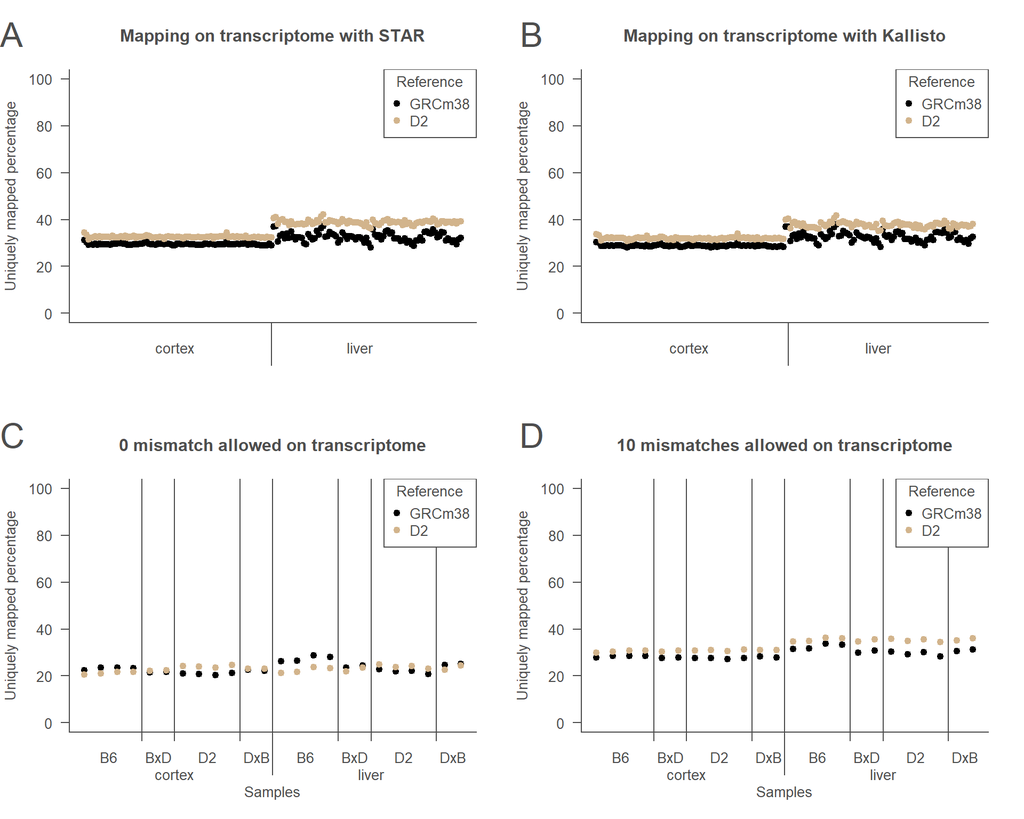

**Figure S1: Consequences of mapping reference transcriptome at read mapping level.**

1. Mappability of all samples on 2 parental assembly transcriptomes using STAR permissive mapping setting.
2. Pseudo-mappability of all samples on 2 parental assembly transcriptomes using Kallisto.
3. Mappability of parental and F1 samples on 2 parental assembly transcriptomes using STAR restrictive mapping setting.
4. Mappability of parental and F1 samples on 2 parental assembly transcriptomes using STAR restrictive mapping setting, but up to 10 mismatches.

## Figure S2: Examples of artefacts of assemblies sequence and annotation.

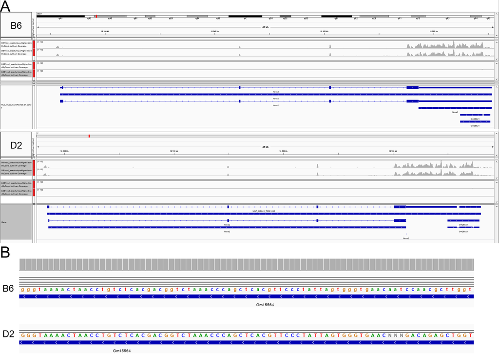

**Figure S2: Examples of artefacts of assemblies sequence and annotation.**

1. *Nova2* genomic region in Integrative Genomics Viewer (IGV), as an transcriptome annotation artefact. The coverage is very similar between B6 and D2 assemblies, but the annotation differs, which causes the reads to be counted differently.
2. *Gm15564* genomic sequence in IGV, as a artefact due to difference in completeness of genome assembly. Many reads map to this region on B6 assembly, but not on D2. It appears that in this region of the D2 assembly there are three unknown nucleotides (with label “N”), which supports the interpretation that it is probably due a difference in assembly quality, and not to a genomic variant.

## Figure S3: Genotype imputation workflow.

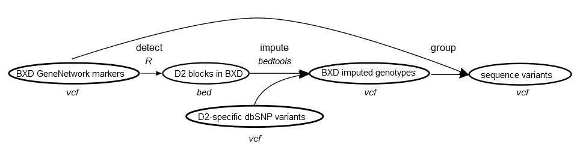

**Figure S3: Genotype imputation workflow.**

## Figure S4: Consequences of mapping reference at local eQTL level in SD condition.

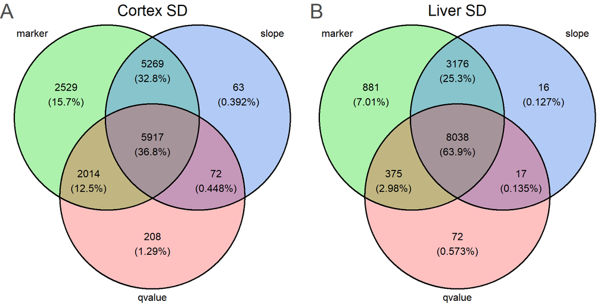

**Figure S4: Consequences of mapping reference at local eQTL level in SD condition.**

1. Local eQTLs overlapping in cortex SD between GRCm38 and BXD-specific references.
2. Local eQTLs overlapping in liver SD between GRCm38 and BXD-specific references.